# S4: riaggregazione unica con MCSE

Roadmap Morris 2019, ramo morris-v4

Data di Pubblicazione

17 ottobre 2026

## In breve (TL;DR)

**Domanda.** Ricalcolare in un solo passaggio tutte le misure di performance dichiarate nel protocollo, ciascuna con la sua MCSE, sull’insieme di dati v4: `results_full/` con le sostituzioni di S3 e lo scenario M1c.

**Cosa abbiamo fatto.** Un aggregatore unico (`R/postrun/agg_v4.R`) su 3.024 celle, 9 metodi, 3 definizioni di usabilita’ e 2 insiemi: 163.296 righe. Le misure: bias, SE empirico, SE del modello, errore relativo, MSE/RMSE, copertura, copertura bias-eliminated, I tipo, potenza grezza e size-adjusted, validita’ incondizionata e quota usabile, tutte con MCSE. La verita’ condizionale di GLMM-AR1 e’ ricalcolata per ciascuno dei 1.008.000 replicati.

**Risultato.** I numeri del v3 si riproducono esattamente dove S3 non ha cambiato nulla (25.539 righe, differenza massima 1,1e-15). Le formule coincidono con quelle del pacchetto indipendente `rsimsum` (5.070 confronti, differenza massima 4,4e-13). 11 attese su 14 superate; le 3 non superate erano formulate male (D-20).

**Due cose da sapere.**

- **Con le pendenze casuali (D-08) il GLMM non e’ stimabile nelle serie piu’ corte**: M3-M4 a T = 2 e M5 a T <= 3 (342 celle). Valeva gia’ per il Wald; ora vale anche per il LRT, che nel v3 usava la sola intercetta casuale. Dove resta stimabile, il LRT corretto rifiuta meno: da -1,2 a -2,5 punti sotto H0 e da -1,6 a -6,6 punti sotto H1, in media sulle celle.
- **Wald `glmer` di default e Wald bobyqa (D-16) differiscono molto in alcune celle** con pendenze casuali, soprattutto in GenBinaryY. Esempio: in M3, N = 145, T = 4, H0, l’I tipo e’ 0,116 contro 0,038 su 1.000 replicati usabili per entrambi. In media le due versioni quasi coincidono. Da valutare in S5 e S7.

**Prossimo passo.** Ok del PI su questo report, poi S5 (inferenza per blocchi e adeguatezza di n_sim), che riusa la matrice degli indici bootstrap salvata qui.

## 1. Pre-registrazione

Attese Q0-Q9 scritte in `docs/sessions/2026-10-17_S4.md` e committate **prima** di qualsiasi calcolo dello step: commit `bae4915`, 2026-10-17 18:21:10 +0200. Nello stesso commit: D-18 (nessuna verita’ condizionale per i metodi condizionali su GenBinaryY, scelta del PI in chat) e D-19 (regole tecniche: quantile z, copertura, MCSE con verita’ per replicato, regola size-adjusted del v3, bootstrap per blocchi). Requisiti Morris toccati: E1, E2, E4, C2.

Perimetro: insieme di righe v4 per D-15 (F1 e F2 per intero, `glmer_lrt` di L, M1c come scenario separato); denominatore D-11; usabilita’ U0/U1/U2 (D-04); verita’ D-12 e D-18; sensibilita’ `glmer_bobyqa` (D-16); effetto di D-08 sul LRT (D-17). Il testo delle attese non e’ stato modificato dopo i risultati.

## 2. Esecuzione

Tutto su lesexp-server, R 4.6.1, `Rscript --vanilla`, libreria `renv/library/linux-ubuntu-noble/R-4.6` con `rsimsum` 0.13.1 aggiunto in apertura (binario PPM). Nessuna simulazione: lo step legge i chunk e rigenera solo i disegni AR1 (stesso seme e RNGkind di D-07).

| script | parte | durata | output principali |
| --- | --- | --- | --- |
| `R/s4/s4_q0.sh` | Q0 prima e dopo | pochi minuti (non cronometrato) | `reports/morris/S4_logs/S4_q0_{pre,post}.log` |
| `R/s4/s4_load.R` | insieme di righe v4 (D-15), usabilita’ U0/U1/U2, `glmer_bobyqa` | 110 s | `results_v4/S4/rows_v4.rds`, `lrt_v3_m3m5.rds`, `sims_s3.rds` |
| `R/s4/s4_truth.R` | verita’ AR1 per replicato (1.008.000), verita’ di M1c GLMM-native, Q6 | 909 s, 45 core | `results_v4/S4/truth_ar1_rep.rds`, `tables/V4_S4_truth_by_cell.csv`, `V4_S4_truth_m1c_native.csv`, `V4_S4_ar1_generator_spec.csv`, `V4_S4_q6_truth_checks.csv` |
| `R/postrun/agg_v4.R` | misure, MCSE, bootstrap per blocchi, Q1-Q2 | 12,7 min, 40 core | `tables/V4_perf_all.csv.gz`, `V4_perf_primary.csv`, `V4_S4_q1_q2.csv`, `results_v4/S4/boot_idx.rds` |
| `R/s4/s4_checks.R` | Q3, Q4, Q5, Q7, Q8, Q9 | circa 2 min | `tables/V4_S4_q3_*.csv` … `V4_S4_q9_*.csv`, `V4_S4_d08_*.csv` |
| `R/s4/s4_tables.R` | tabelle di questo report | secondi | `reports/morris/S4_results.md`, `tables/V4_S4_expectations.csv` |

| file | ruolo | md5 |
| --- | --- | --- |
| results_v4/S2/rows_timetrt.rds | input (V-15) | 092a5ad60b60e0ea28cb6b78ba2adbeb |
| baseline/results_full_md5.txt | input, sola lettura | cb9cfde75e4a62de2ac4aa5a2996cb7a |
| baseline/results_v4_S3_md5.txt | input S3 | 055664eec91881f13bac99f8b6d35322 |
| baseline/results_v4_S4_md5.txt | intermedi di S4 (non tracciati) | e07998dc19173a4aa7923db6eae5f0fd |
| R/s4/s4_common.R | codice eseguito | 606aae08de592ba43d163fc9a762b475 |
| R/s4/s4_load.R | codice eseguito | 0b0747bba4d81e4f0b1ba46d50a824ef |
| R/s4/s4_truth.R | codice eseguito | cbdd15b59552c3ef0763a5b9b4fcfd3a |
| R/postrun/agg_v4.R | codice eseguito | bfb68eaca291b6c71ff02140db9b426e |
| R/s4/s4_checks.R | codice eseguito | d579909029f8f5e3a27b8d6f11b7dca1 |
| R/s4/s4_tables.R | codice eseguito | cec11b0ea058a0607aca614ce8794ee5 |
| tables/V4_perf_all.csv.gz | output: tutte le combinazioni | 4b41db8eb21102f88466b04989cccea2 |
| tables/V4_perf_primary.csv | output: analisi primaria (U0, own) | 0ef9350d7efc4227f2db868c328cd88c |
| tables/V4_S4_truth_by_cell.csv | output: valori veri per cella | 54e5ff2d61eba11ce36f15f95671a05f |

**Correzioni durante lo step.** Tutte riguardano strumenti; nessuna ha cambiato un’attesa, una misura o una regola di D-19.

1. `s4_truth.R`: una sostituzione con `sed` aveva lasciato `"\1"` (carattere ottale) al posto di `"\\1"` nell’estrazione del numero di scenario; il job si e’ fermato su `set.seed(NA)` prima di produrre risultati. Corretto e rilanciato.
2. `agg_v4.R`, prova su 3 design point: il conteggio dei duplicati raggruppava per una chiave che contiene la colonna `N` (numero di cluster) e il filtro `N > 1` leggeva quella invece del conteggio; con un nome esplicito i duplicati sono 0. Nella stessa prova il controllo Q1c guardava solo le righe `time:trt`: affiancata la versione “qualunque riga”, che e’ quella pre-registrata.
3. `agg_v4.R`, primo run completo: 5 design point fallivano nel bootstrap perche’ `apply(..., cumsum)` su una matrice a una colonna restituisce un vettore (celle con un solo replicato H1 usabile). Corretto con una funzione che conserva la forma; rilanciato per intero.
4. `s4_load.R`: le righe `glmer_lrt` del v3 venivano messe da parte dopo aver rimosso le celle F1 e F2, quindi i gruppi “D-01 + D-08” e “D-02 + D-08” di Q8 erano vuoti. Spostata l’estrazione prima della rimozione e rigenerato: `rows_v4.rds` ha lo stesso md5 prima e dopo (`ca455b76895a3b8209a80dfa82aced82`, `S4_logs/S4_rows_md5_run{1,2}.txt`); cambia solo `lrt_v3_m3m5.rds`. Controlli rilanciati.
5. `s4_tables.R`: `.libPaths()` mancante (lettura del `.gz`) e filtro delle righe di Q0 che includeva l’intestazione con la data.

## 3. Esito

### Tabella E. Attese pre-registrate e osservato

| id | attesa | tolleranza | osservato | superato |
| --- | --- | --- | --- | --- |
| Q0 | md5 di results_full/ (28.800), results_v4 S2 (126) e S3 (18.720) e di rows_timetrt.rds invariati prima e dopo | zero falliti | prima: results_full: 28800 checked, 0 FAIL lines; results_v4 S2: 126 checked, 0 FAIL lines; results_v4 S3: 18720 checked, 0 FAIL lines; rows_timetrt.rds 092a5ad60b60e0ea28cb6b78ba2adbeb (expected 092a… | si |
| Q1a | nessuna riga glmer_lrt v3 in M3-M5; re_structure come D-08 in M3-M5 e (1\|id) in M1c | esatta | righe v3: 0; re_structure inattese: 0 | si |
| Q1b | celle F1 e F2 interamente da S3 | esatta | righe non da S3: 0 | si |
| Q1c | 3.024 celle, 1.512 design point, ogni cella con righe per tutti gli 8 metodi primari | esatta | celle 3.024, design point 1.512; celle con meno di 8 metodi: 342 (qualunque riga), 342 (righe time:trt); duplicati 0 | no |
| Q1d | tabella lunga 3.024 x 9 x 3 x 2 = 163.296 righe | esatta | 163.296 | si |
| Q2 | n_den: 2.878.518 (griglia) e 143.742 (M1c); zero righe U0 su chiavi degeneri; ogni chiave non degenere con una riga di analisi | esatta | 2.878.518; 143.742; U0 su degeneri 0; chiavi senza righe 0 | si |
| Q3 | righe non toccate da S3 riproducono O_level_all (n, k_rej) e O_coverage_all (n, cov_gen) | 100%, 1e-12 | O_level_all (H0): 12.395/12.395 n uguali, diff. max 5.3e-16, mancanti 0, inverse mancanti 0; O_coverage_all (H1): 13.144/13.144 n uguali, diff. max 1.1e-15, mancanti 0 | si |
| Q4 | n_U0, n_U1, n_U2 = V4_S2_usable_by_cell nelle combinazioni non toccate | esatta | 17.725 righe; U0 17.725, U1 17.725, U2 17.725 uguali; mancanti 0 | si |
| Q5a | rsimsum 0.13.1 su 300 combinazioni: 17 misure e MCSE entro 1e-10 | 1e-10 | 5.070 confronti, oltre tolleranza 0, diff. max 4.4e-13 | si |
| Q5b | MSE = bias^2 + SE empirico^2 (n - 1)/n in tutte le combinazioni con n_obs >= 2 | 1e-12 | marginal: 0/100.893 oltre, diff. max 2.9e-14; conditional per replicate: 10.052/10.580 oltre, diff. max 4.5e-03; conditional: 0/10.579 oltre, diff. max 2.1e-13 | no |
| Q6 | verita’ AR1 per replicato (riproduzione S2, biiezione con i degeneri, replay = generatore); quadratura M1 | 1e-12; < 1e-8 | S2 reproduction M1-M4: ok; failures = degenerate keys, main: ok; failures = degenerate keys, M1c: ok; replay = generator, 200 keys: ok; quadrature reproduces S2 M1: ok | si |
| Q7 | SE bootstrap della potenza grezza entro il 10% dalla MCSE binomiale | >= 95% | 58.198/58.198 (1,0000); rapporto mediano 1,000 | si |
| Q8 | D-08: ogni cella del blocco L con almeno un replicato usabile in entrambe le versioni | 100% | 1.021/1.248 | no |
| Q9 | glmer_bobyqa: p = 2 Phi(-abs(z)); n_obs <= n_obs(glmer_lrt) per cella | esatta | p diversi 0 su 2.634.153 righe; celle 3.024/3.024 (eccesso massimo 0) | si |

### E1. Q1c: celle senza righe time:trt per un metodo primario

| metodo | scenario | T | coppie cella x metodo | con righe | solo righe di fallimento | glmer mai convergente nella cella | motivo piu’ frequente |
| --- | --- | --- | --- | --- | --- | --- | --- |
| glmer | M3 | 2 | 84 | 84 | 84 | 84 | number of observations (=34) < number of random effects (=40) for term |
| glmer | M4 | 2 | 84 | 84 | 84 | 84 | number of observations (=59) < number of random effects (=70) for term |
| glmer | M5 | 2 | 96 | 96 | 96 | 96 | number of observations (=34) < number of random effects (=60) for term |
| glmer | M5 | 3 | 78 | 78 | 78 | 78 | number of observations (=65) < number of random effects (=75) for term |
| glmer_lrt | M3 | 2 | 84 | 84 | 84 | 84 | fit returned NULL |
| glmer_lrt | M4 | 2 | 84 | 84 | 84 | 84 | fit returned NULL |
| glmer_lrt | M5 | 2 | 96 | 96 | 96 | 96 | fit returned NULL |
| glmer_lrt | M5 | 3 | 78 | 78 | 78 | 78 | fit returned NULL |
| shrink | M3 | 2 | 84 | 0 | 0 | 84 |  |
| shrink | M4 | 2 | 84 | 0 | 0 | 84 |  |
| shrink | M5 | 2 | 96 | 0 | 0 | 96 |  |
| shrink | M5 | 3 | 78 | 0 | 0 | 78 |  |

### E2. Quota usabile per definizione (griglia principale, entrambi gli arm, denominatore D-11)

| method | U0 | U1 | U2 |
| --- | --- | --- | --- |
| gee | 0,942 | 0,938 | 0,942 |
| gee_fg | 0,922 | 0,922 | 0,922 |
| gee_kc | 0,922 | 0,922 | 0,922 |
| gee_md | 0,922 | 0,922 | 0,922 |
| glmer | 0,811 | 0,635 | 0,635 |
| glmer_bobyqa | 0,813 | 0,769 | 0,769 |
| glmer_lrt | 0,865 | 0,798 | 0,798 |
| mmm | 0,907 | 0,783 | 0,907 |
| shrink | 0,821 | 0,640 | 0,640 |

### E3. MCSE nell’analisi primaria (U0, own; celle con n_obs >= 100)

Scala: proporzioni (I tipo, copertura, potenza, quota usabile), unita’ del coefficiente (bias, SE empirico), punti percentuali (errore relativo dello SE).

| misura | arm | combinazioni | MCSE mediana | MCSE massima |
| --- | --- | --- | --- | --- |
| rej | H0 | 12.738 | 0.0077 | 0.0324 |
| rej | H1 | 12.752 | 0.0105 | 0.0314 |
| cover | H1 | 10.558 | 0.0077 | 0.0314 |
| becover | H1 | 11.432 | 0.0078 | 0.0313 |
| bias | H1 | 10.558 | 0.0093 | 0.2214 |
| empse | H1 | 11.432 | 0.0068 | 0.1781 |
| relerr_modse | H1 | 11.432 | 2.2916 | 51.4197 |
| power_sa | H1 | 12.752 | 0.0126 | 0.4026 |
| p_usable | H0 | 12.738 | 0.0000 | 0.0160 |

### E4. Valori veri di M1c in GLMM-native (quadratura, Q6c descrittivo)

| arm | T | condizionale | marginale | errore 40 vs 80 nodi |
| --- | --- | --- | --- | --- |
| H0 | 2 | 0,000000 | 0,000569 | 1.1e-08 |
| H0 | 3 | 0,000000 | 0,000568 | 9.5e-09 |
| H0 | 4 | 0,000000 | 0,000569 | 8.3e-09 |
| H0 | 6 | 0,000000 | 0,000572 | 5.3e-09 |
| H1 | 2 | 0,298393 | 0,190843 | 4.1e-08 |
| H1 | 3 | 0,298393 | 0,192294 | 2.6e-08 |
| H1 | 4 | 0,298393 | 0,193990 | 1.1e-08 |
| H1 | 6 | 0,298393 | 0,197849 | 7.3e-09 |

| controllo | chiavi | valore | discordanze NA | superato |
| --- | --- | --- | --- | --- |
| Q6a S2 reproduction M1-M4 | 9.600 | 5.6e-16 | 0 | si |
| Q6a failures = degenerate keys, main | 960.000 | 1.0e-08 | 0 | si |
| Q6a failures = degenerate keys, M1c | 48.000 | 1.0e-08 | 0 | si |
| Q6b replay = generator, 200 keys | 200 | 0.0e+00 | 0 | si |
| Q6c quadrature reproduces S2 M1 | 12 | 4.4e-16 | 0 | si |

### E5. Controprova rsimsum (Q5a) e identita’ (Q5b)

| controllo | combinazioni | confronti | diff. max | oltre tolleranza | tolleranza |
| --- | --- | --- | --- | --- | --- |
| rsimsum n | 300 | 300 | 0.0e+00 | 0 | 1.0e-10 |
| rsimsum bias | 300 | 300 | 4.2e-16 | 0 | 1.0e-10 |
| rsimsum empse | 300 | 300 | 4.9e-15 | 0 | 1.0e-10 |
| rsimsum modse | 300 | 300 | 5.1e-15 | 0 | 1.0e-10 |
| rsimsum relerr | 300 | 300 | 4.4e-13 | 0 | 1.0e-10 |
| rsimsum mse | 300 | 300 | 5.3e-15 | 0 | 1.0e-10 |
| rsimsum cover | 300 | 300 | 6.7e-16 | 0 | 1.0e-10 |
| rsimsum becover | 300 | 300 | 6.7e-16 | 0 | 1.0e-10 |
| rsimsum power | 300 | 300 | 5.6e-16 | 0 | 1.0e-10 |
| rsimsum mcse_bias | 300 | 270 | 4.7e-16 | 0 | 1.0e-10 |
| rsimsum mcse_empse | 300 | 300 | 3.9e-16 | 0 | 1.0e-10 |
| rsimsum mcse_modse | 300 | 300 | 3.3e-16 | 0 | 1.0e-10 |
| rsimsum mcse_relerr | 300 | 300 | 5.0e-14 | 0 | 1.0e-10 |
| rsimsum mcse_mse | 300 | 300 | 4.7e-16 | 0 | 1.0e-10 |
| rsimsum mcse_cover | 300 | 300 | 6.2e-17 | 0 | 1.0e-10 |
| rsimsum mcse_becover | 300 | 300 | 6.2e-17 | 0 | 1.0e-10 |
| rsimsum mcse_power | 300 | 300 | 5.2e-17 | 0 | 1.0e-10 |
| identity MSE, marginal | 100.893 | 100.893 | 2.9e-14 | 0 | 1.0e-12 |
| identity MSE, conditional per replicate | 10.580 | 10.580 | 4.5e-03 | 10.052 | 1.0e-12 |
| identity MSE, conditional | 10.579 | 10.579 | 2.1e-13 | 0 | 1.0e-12 |

### E6. Effetto di D-08 sul LRT: differenza appaiata v4 - v3 (U0), media sulle celle

d I tipo/potenza: differenza del tasso di rifiuto sui replicati usabili in entrambe le versioni; d usabile: differenza della quota usabile sui replicati con disegno stimabile. Celle oltre 2 MCSE appaiate.

| gruppo | meccanismo | scenario | arm | celle | d rifiuto medio | celle oltre 2 MCSE (rifiuto) | d usabile medio | celle oltre 2 MCSE (usabile) | n appaiati minimo |
| --- | --- | --- | --- | --- | --- | --- | --- | --- | --- |
| D-01 + D-08 | GenBinaryY | M3 | H0 | 96 | -0,0455 | 80 | -0,1644 | 16 | 0 |
| D-01 + D-08 | GenBinaryY | M4 | H0 | 96 | -0,0455 | 80 | -0,1647 | 18 | 0 |
| D-01 + D-08 | GenBinaryY | M5 | H0 | 96 | -0,0357 | 53 | -0,3317 | 38 | 0 |
| D-02 + D-08 | GLMM-AR1 | M5 | H0 | 96 | -0,0151 | 28 | -0,3329 | 39 | 0 |
| D-02 + D-08 | GLMM-AR1 | M5 | H1 | 96 | -0,0380 | 56 | -0,3331 | 39 | 0 |
| D-08 only | GLMM-AR1 | M3 | H0 | 96 | -0,0248 | 78 | -0,1648 | 16 | 0 |
| D-08 only | GLMM-AR1 | M3 | H1 | 96 | -0,0425 | 78 | -0,1650 | 17 | 0 |
| D-08 only | GLMM-AR1 | M4 | H0 | 96 | -0,0222 | 70 | -0,1651 | 17 | 0 |
| D-08 only | GLMM-AR1 | M4 | H1 | 96 | -0,0246 | 72 | -0,1652 | 17 | 0 |
| D-08 only | GLMM-native | M3 | H0 | 96 | -0,0196 | 64 | -0,1651 | 16 | 0 |
| D-08 only | GLMM-native | M3 | H1 | 96 | -0,0376 | 79 | -0,1652 | 17 | 0 |
| D-08 only | GLMM-native | M4 | H0 | 96 | -0,0165 | 71 | -0,1653 | 17 | 0 |
| D-08 only | GLMM-native | M4 | H1 | 96 | -0,0165 | 60 | -0,1654 | 17 | 0 |
| D-08 only | GLMM-native | M5 | H0 | 96 | -0,0124 | 33 | -0,3329 | 38 | 0 |
| D-08 only | GLMM-native | M5 | H1 | 96 | -0,0290 | 54 | -0,3333 | 38 | 0 |
| D-08 only | GenBinaryY | M3 | H1 | 96 | -0,0661 | 79 | -0,1646 | 16 | 0 |
| D-08 only | GenBinaryY | M4 | H1 | 96 | -0,0490 | 80 | -0,1648 | 18 | 0 |
| D-08 only | GenBinaryY | M5 | H1 | 96 | -0,0656 | 61 | -0,3318 | 39 | 0 |

### E7. Wald glmer (default) e Wald bobyqa (D-16), media sulle celle con n_obs >= 100 per entrambi

| meccanismo | arm | celle | rifiuto glmer | rifiuto bobyqa | celle con abs(z) > 2 (z non appaiato, conservativo) | quota usabile glmer | quota usabile bobyqa |
| --- | --- | --- | --- | --- | --- | --- | --- |
| GLMM-AR1 | H0 | 412 | 0,0648 | 0,0649 | 88 | 0,945 | 0,947 |
| GLMM-AR1 | H1 | 414 | 0,2789 | 0,2800 | 59 | 0,946 | 0,948 |
| GLMM-native | H0 | 414 | 0,0621 | 0,0616 | 80 | 0,944 | 0,946 |
| GLMM-native | H1 | 414 | 0,2682 | 0,2697 | 47 | 0,949 | 0,951 |
| GenBinaryY | H0 | 412 | 0,0857 | 0,0825 | 117 | 0,930 | 0,934 |
| GenBinaryY | H1 | 413 | 0,3036 | 0,3036 | 98 | 0,934 | 0,938 |

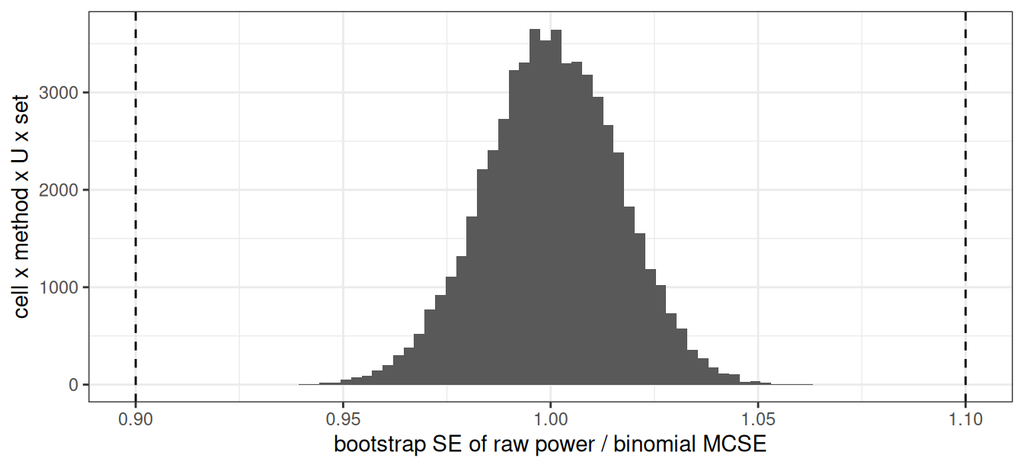

Figura 1

*Cosa guardare*: la distribuzione del rapporto fra la SE bootstrap della potenza grezza e la MCSE binomiale, centrata su 1 e tutta dentro le linee al 10% (Q7). *Segnale d’errore*: un rapporto sistematicamente diverso da 1, che indicherebbe ricampionamenti sbagliati (indici non accoppiati fra H0 e H1, o chiavi degeneri non escluse). La stessa macchina produce la MCSE della potenza size-adjusted.

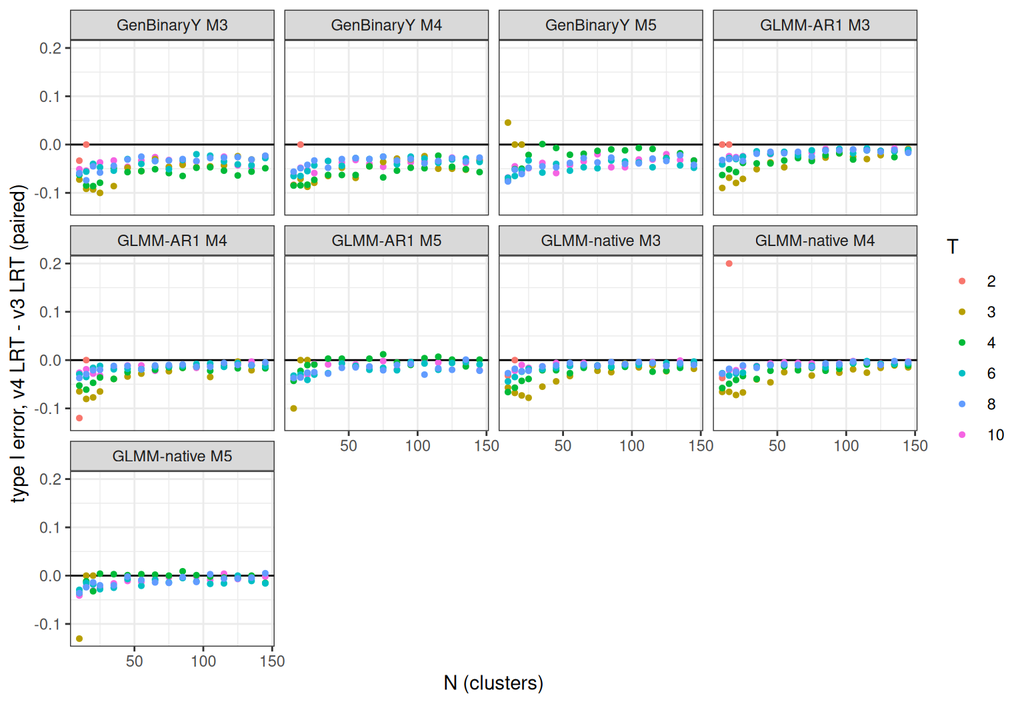

Figura 2

*Cosa guardare*: sotto H0 la differenza appaiata dell’errore di I tipo del LRT fra la versione con pendenze casuali (v4) e quella con sola intercetta (v3), per cella; i pannelli GenBinaryY e GLMM-AR1 M5 sommano D-01 o D-02 a D-08. *Segnale d’errore*: differenze diverse da zero in M1-M2 (dove il LRT non cambia: non compaiono qui perche’ fuori dal confronto) o uno spostamento positivo, che contraddirebbe S3 (V-42: -0,046 in GenBinaryY M3-M4).

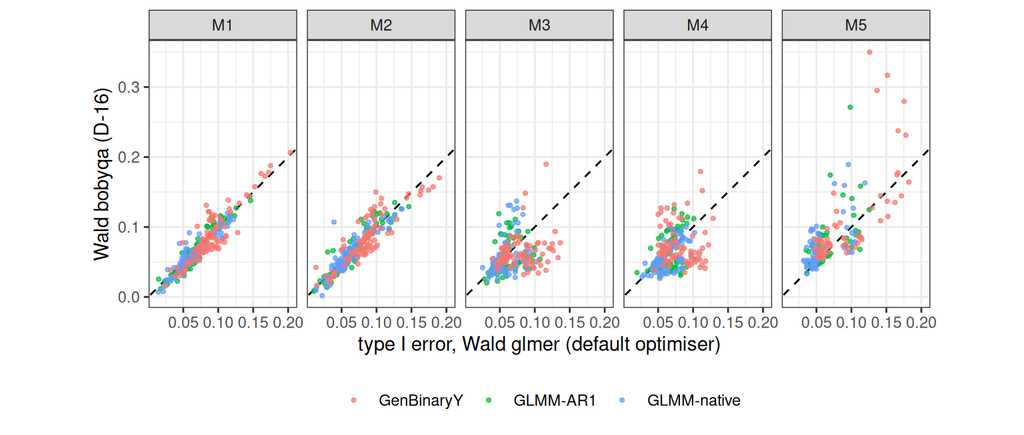

Figura 3

*Cosa guardare*: in M1-M2 (sola intercetta casuale) i punti stanno sulla diagonale; in M3-M5 (pendenze casuali) se ne allontanano, soprattutto in GenBinaryY, nelle due direzioni. *Segnale d’errore*: punti lontani dalla diagonale anche in M1-M2, che indicherebbero righe `glmer_bobyqa` costruite male invece di una differenza fra ottimizzatori.

### Come leggere le tabelle

- **Tabella E.** Cosa guardare: la colonna “superato”. *Segnale d’errore*: un “si” con un “osservato” che contraddice la tolleranza.
- **E1.** Cosa guardare: tutte le coppie cella x metodo senza righe `time:trt` sono M3-M4 a T = 2 o M5 a T <= 3, con il solo errore di identificabilita’ delle pendenze casuali; `shrink` manca dove `glmer` non converge mai. *Segnale d’errore*: una coppia in M1-M2 o a T >= 4 (M3-M4), oppure un motivo diverso.
- **E2.** Cosa guardare: la caduta di U1 per `glmer`, `shrink` e `mmm` (warning frequenti), e `glmer_lrt` a 0,865 (era 0,997 nel v3) per le celle non stimabili. *Segnale d’errore*: U2 piu’ basso di U1, impossibile per costruzione.
- **E3.** Cosa guardare: la MCSE mediana dell’I tipo (0,0077) vicina al valore atteso con 1.000 replicati (0,0069, protocollo sez. 6). *Segnale d’errore*: MCSE nulle dove n_obs > 0 e la misura non e’ 0 o 1.
- **E4.** Cosa guardare: la verita’ marginale di M1c in GLMM-native (0,191-0,198 sotto H1; 0,00057 sotto H0, non 0) da dichiarare in S7 come per M1-M5 (D-12).
- **E6.** Cosa guardare: segno negativo in tutte le righe; d usabile di circa -1/6 in M3-M4 e -1/3 in M5, cioe’ le colonne T = 2 (e T = 3) perse. *Segnale d’errore*: d usabile negativo anche a T >= 4.
- **E7.** Cosa guardare: medie quasi uguali ma molte celle con differenze oltre 2 MCSE (z non appaiato, quindi conservativo). *Segnale d’errore*: differenze in M1-M2.

### Attese non superate (D-20)

- **Q1c** (ogni cella con righe per tutti gli 8 metodi primari): 342 celle su 3.024 senza righe `time:trt` per `glmer`, `glmer_lrt` e `shrink` (1.026 coppie, E1). Causa: con pendenze casuali il GLMM non e’ identificabile in M3-M4 a T = 2 e in M5 a T <= 3 (lme4: “number of observations < number of random effects”); `glmer` e `glmer_lrt` lasciano solo righe di fallimento, e `shrink` non ha righe perche’ nasce da un `glmer` convergente (S2, Q2.2). L’attesa presupponeva una riga per ogni metodo in ogni cella. Nell’aggregazione queste celle hanno n_obs = 0 e quota usabile 0, come devono.
- **Q8** (ogni cella del blocco L con replicati appaiati v4/v3): 1.021/1.248. Le 227 celle senza coppie sono tutte celle in cui il LRT v4 non e’ mai usabile e tutte compaiono nella lista di Q1c (`S4_logs/S4_q8_cells_without_pairs.csv`): stessa causa.
- **Q5b** (MSE = bias^2 + SE empirico^2 (n - 1)/n): vale entro 2,1e-13 con verita’ costante (111.472 combinazioni), non con la verita’ AR1 per replicato (10.052 su 10.580 oltre 1e-12). Con una verita’ che cambia per replicato l’identita’ corretta usa la varianza di (stima - vero), non quella della stima: l’attesa era formulata senza tenerne conto. Il valore dell’MSE e’ confermato da `rsimsum` anche sulle combinazioni con verita’ per replicato (Q5a).

## 4. Controprova

Il test che smentirebbe lo step e’ Q3 insieme a Q5a. Se l’insieme di righe, il filtro di usabilita’ o il denominatore fossero sbagliati, l’aggregatore non riprodurrebbe le tabelle del v3 nelle righe non toccate da S3: 12.395/12.395 righe di `O_level_all` e 13.144/13.144 di `O_coverage_all`, con n identico e differenza massima 1,1e-15. Se una formula di Morris fosse codificata male, `rsimsum`, scritto da altri e con selezione dei replicati rifatta in modo indipendente, darebbe valori diversi: 17 misure e MCSE su 300 combinazioni, differenza massima 4,4e-13. Q4 aggiunge la riproduzione delle tre definizioni di usabilita’ di S2 (17.725/17.725).

## Verdetto

**Chiuso.** Tabelle `V4_perf_*` complete (163.296 righe, Q1d), con insieme di righe v4 conforme a D-15 (Q1a, Q1b), denominatori di D-11 (Q2), riproduzione esatta del v3 e di S2 nelle parti invariate (Q3, Q4), formule e MCSE verificate in modo indipendente (Q5a), valori veri verificati (Q6), bootstrap verificato (Q7). Le tre attese non superate (Q1c, Q5b, Q8) erano formulate male; la causa e’ documentata e il PI ha deciso in chat di registrarle come tali (D-20), senza nuovi calcoli.

Requisiti Morris aggiornati in `docs/audit/MORRIS2019_conformita.csv`: E1 calcolato (tutte le misure dichiarate con MCSE; il reporting si chiude in S6-S7), E2 calcolato (U0/U1/U2 per cella e metodo), C2 applicato (verita’ per estimando, D-18), E4 avanzato (MCSE bootstrap della potenza size-adjusted; rango, worst case e Spearman in S5).